# Prognolite Projektarbeit

## 2.2 Scatterplots

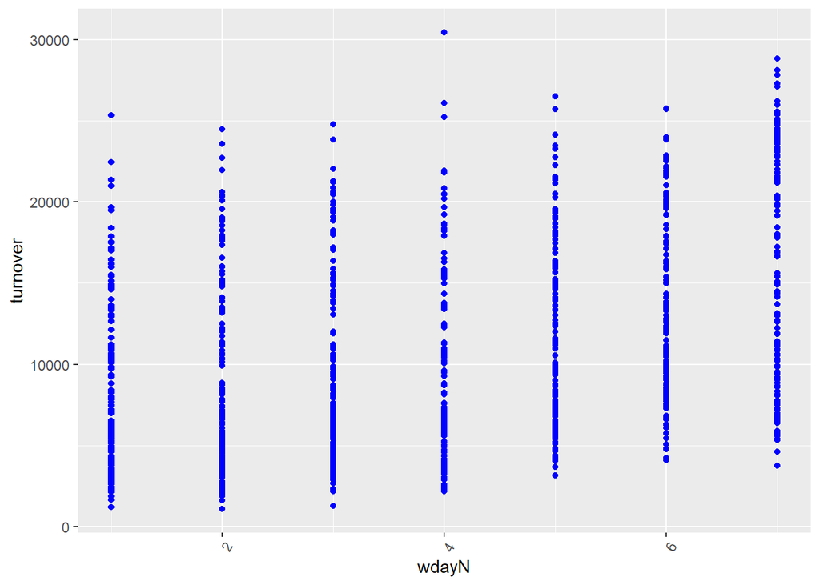

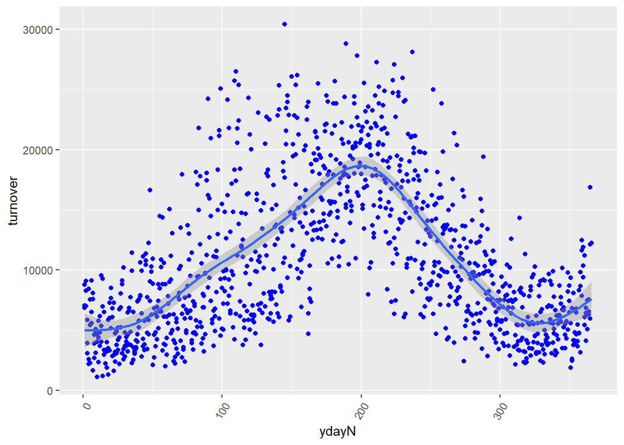

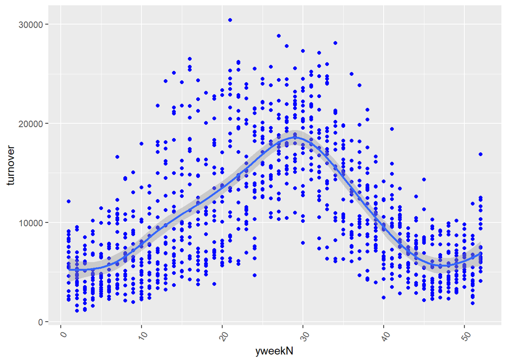

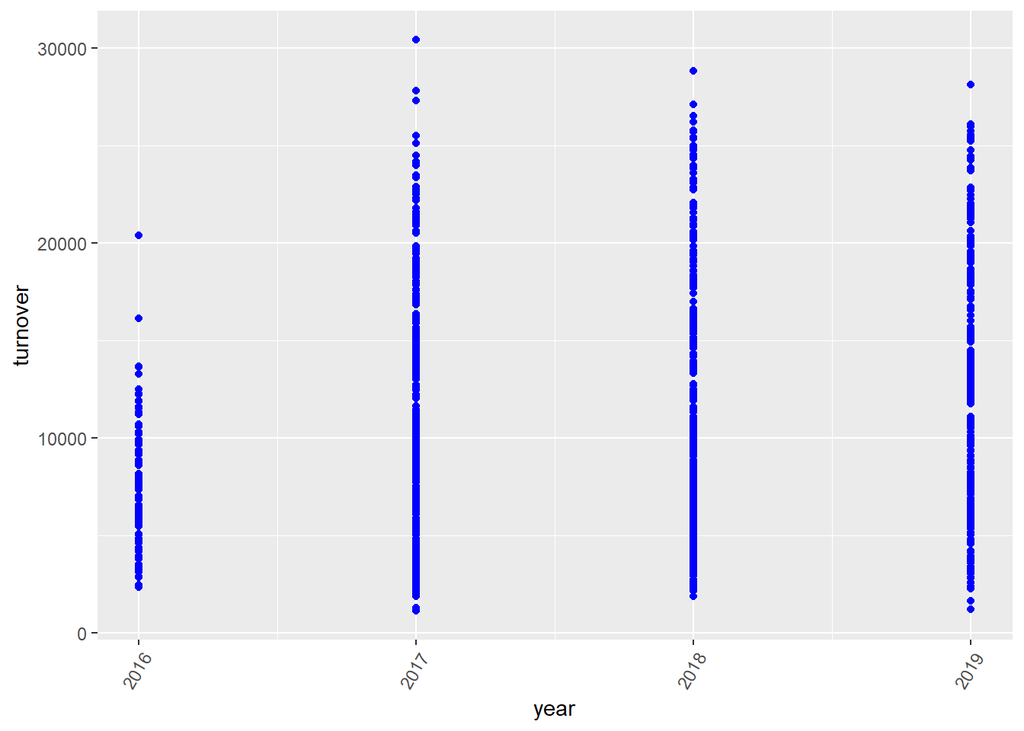

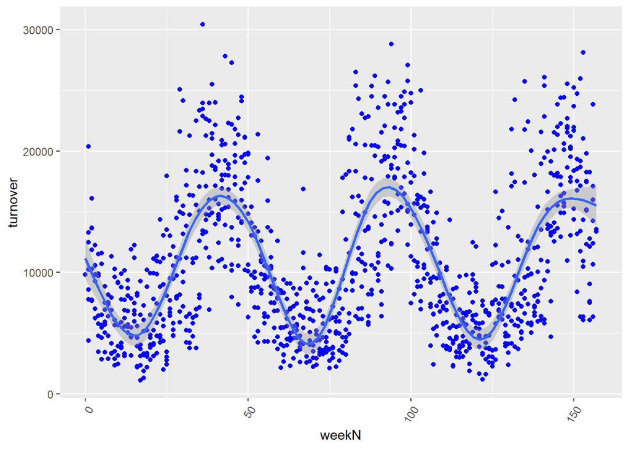

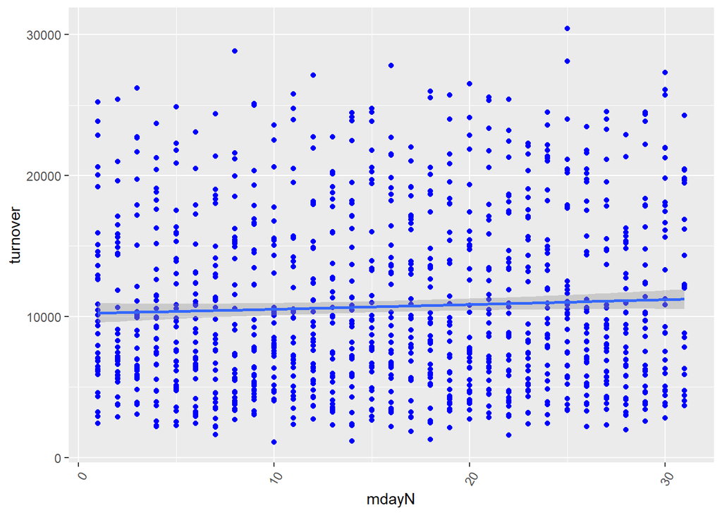

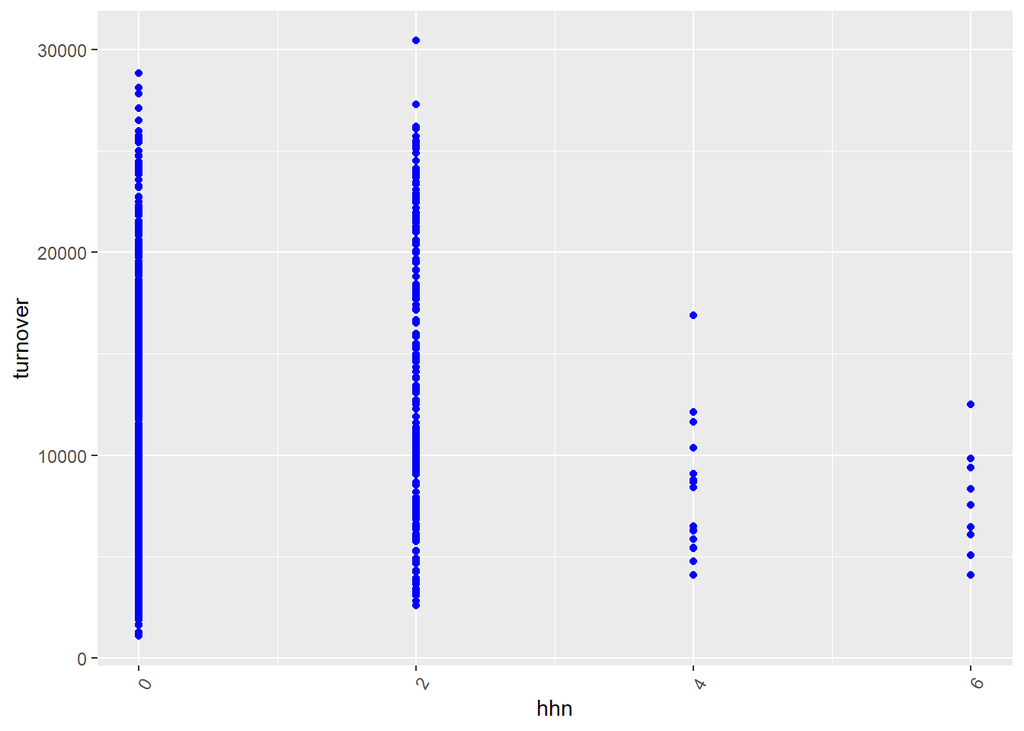

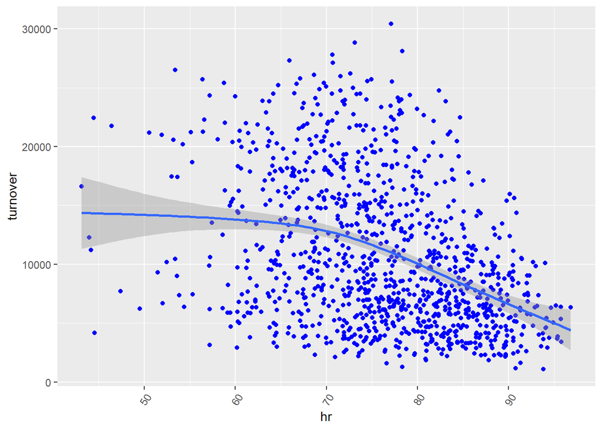

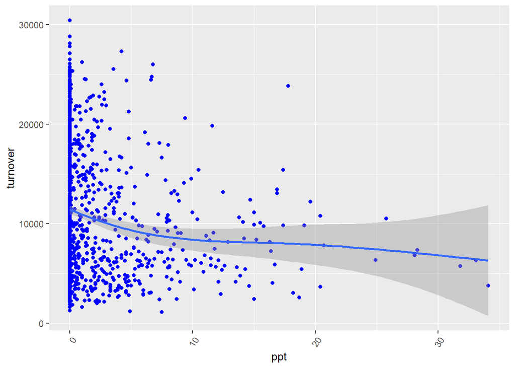

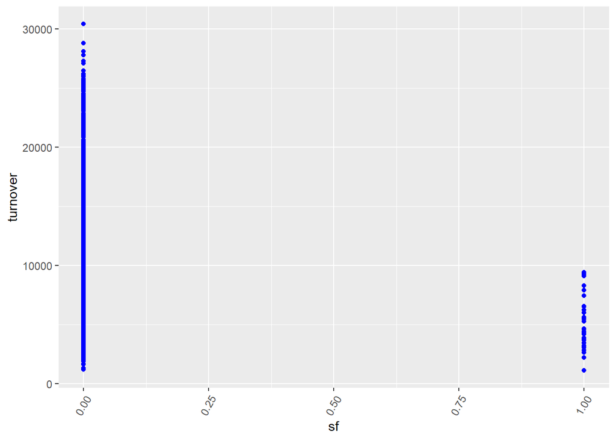

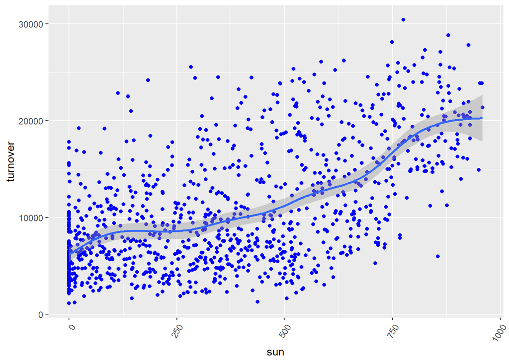

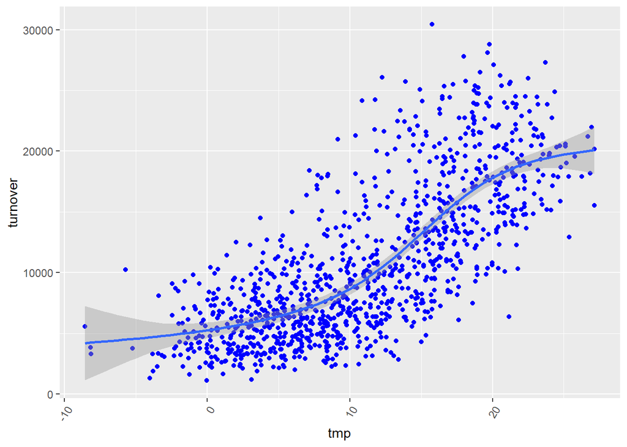

[2 more figures not shown]

```r
# scatterplot turnover against weather variables
dep_var <- "turnover"
indep_vars <- colnames(df)

indep_vars <- nums
for (i in seq(1,length(indep_vars), by=1)){
  p <- ggplot(df, aes_string(x=indep_vars[i], y=dep_var)) +
    #labs(x=labels_df[i], y=tail(labels_df,1)) +
    geom_point(color="blue") +
    theme(axis.text.x = element_text(angle=60, hjust=1))
  p <- p + geom_smooth()
  print(p)
}
```

## 2.3 Boxplots

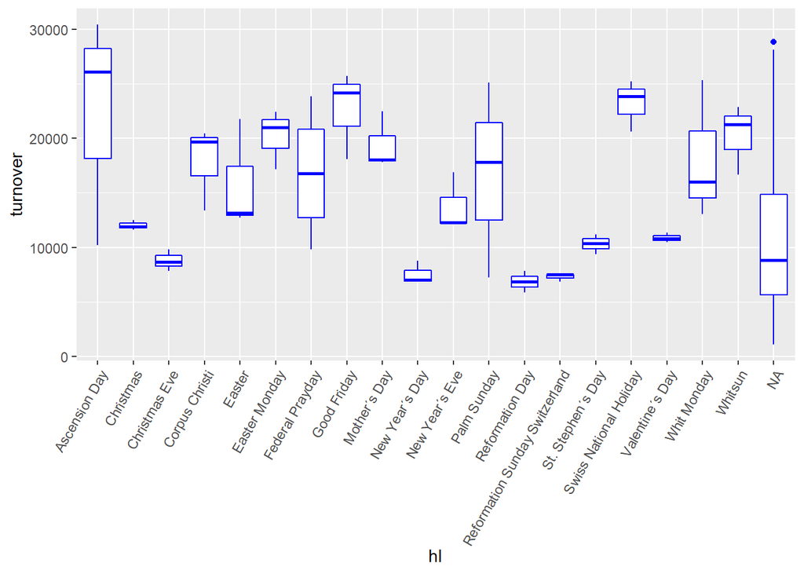

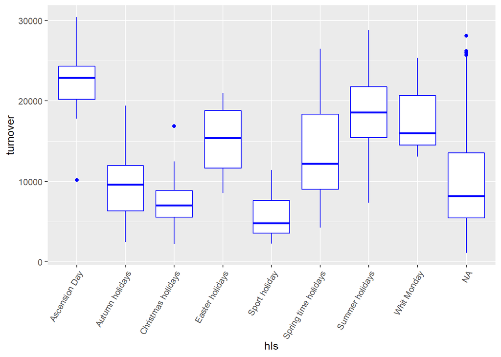

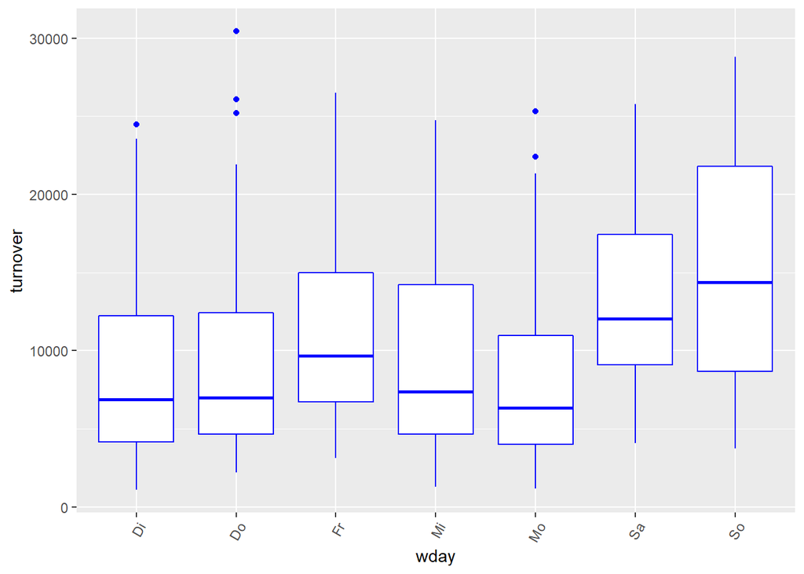

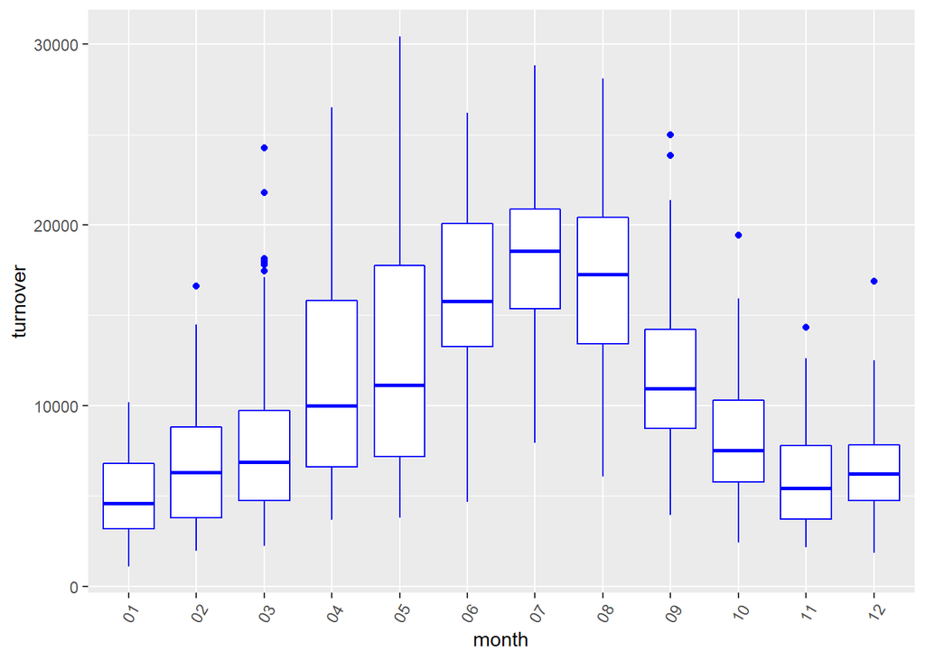

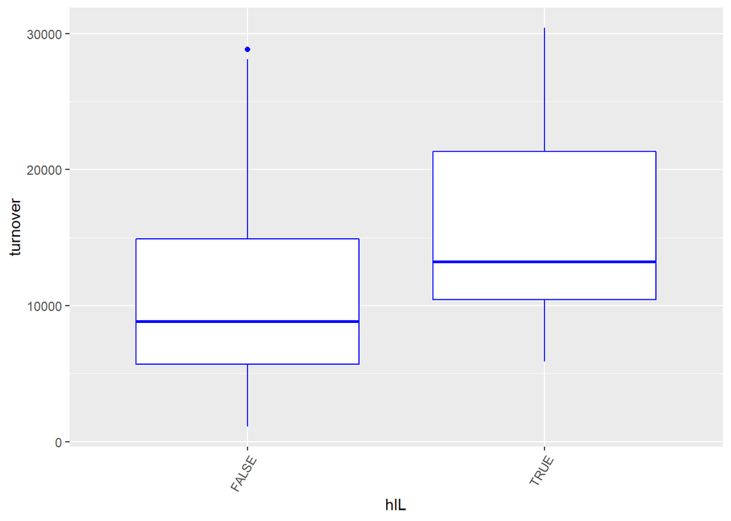

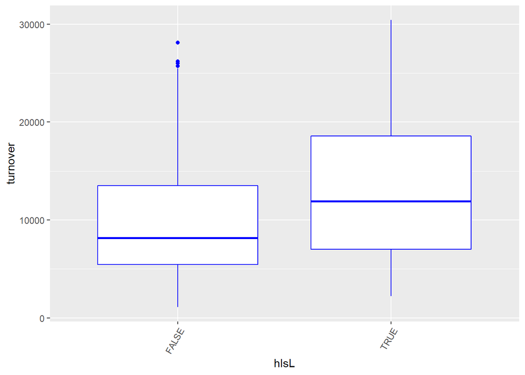

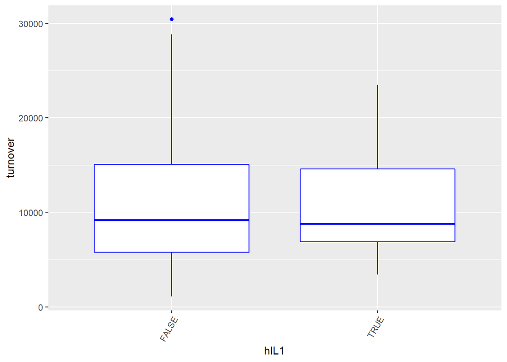

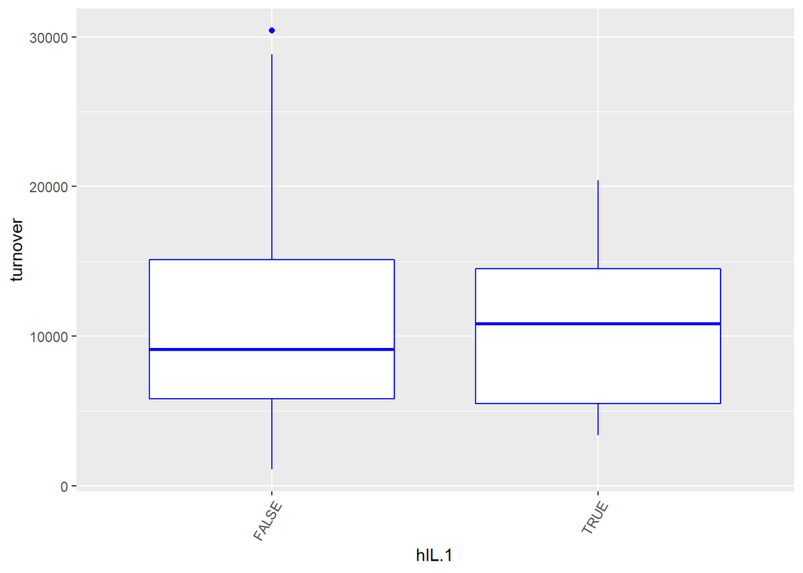

```r
# boxplot turnover against date vars + snow fraction
indep_vars <- c(chars,logicals)
dep_var <- "turnover"
for (i in seq(1,length(indep_vars), by=1)){
  p <- ggplot(df, aes_string(x=indep_vars[i], y=dep_var)) +
    #labs(x=labels_df[i], y=tail(labels_df,1)) +
    geom_boxplot(color="blue") +
    theme(axis.text.x = element_text(angle=60, hjust=1))
  print(p)
}
```

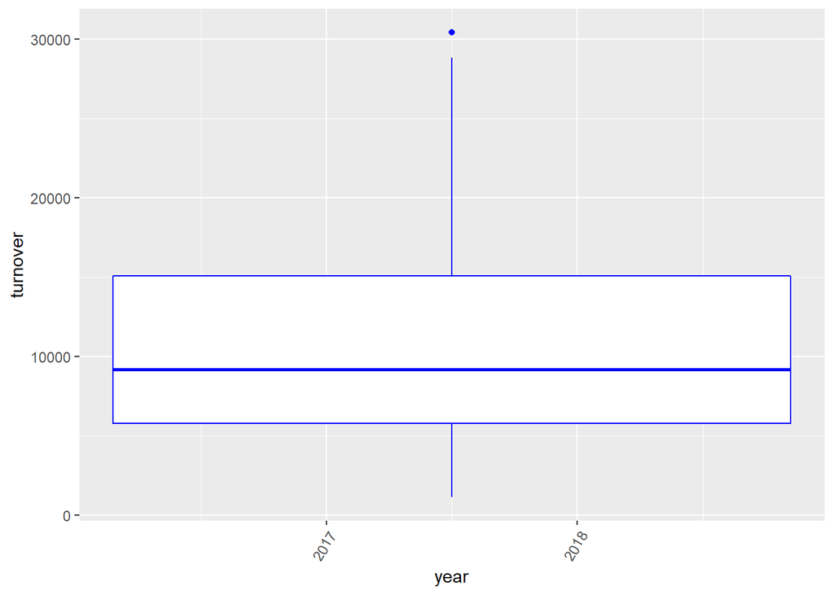

```r
p <- ggplot(df, aes(x=year, y=turnover)) +
  #labs(x=labels_df[i], y=tail(labels_df,1)) +
  geom_boxplot(color="blue") +
  theme(axis.text.x = element_text(angle=60, hjust=1))
print(p)
```

## 2.4 Kandidaten für die multivariate Analyse

- Datumsvariablen: Der mittlere Jahresumsatz ist zwischen 2016 und 2019 angestiegen. Dabei ist er in den Sommermonaten höher als im restlichen Jahr. Weiter ist der Umsatz an den Wochenenden (Freitag bis Sonntag) höher als an Arbeitstagen. $\rightarrow$ Variablen: year, month, wday/wdayN
- Feiertage und Ferien: Der Umsatz schwankt stark über die verschiedenen Feiertagen und Ferien. Zum Beispiel liegt er an gewissen Feiertagen über dem Jahresmittel, an anderen deutlich darunter (1. August vs. Reformierungssonntag). Während den Auffahrtstagen liegt er besonders hoch. Ebenfalls liegt er höher an Tagen vor Feiertagen. ?Anzahl halber Feiertage pro Woche (hhn)? $\rightarrow$ Variablen: hl/hlL, hls/hlsL, hlL.1
- Wettervariablen: Der Umsatz variert stark je nach Wetter. Er ist höher bei trockenen, windstillen und sonnigen Wetter mit höheren Temperaturen (und keinem Schnee). $\rightarrow$ hr, ppt, tmp, sf, sun, ws

## 2.5 Carrelogram - Korrelationsanalyse

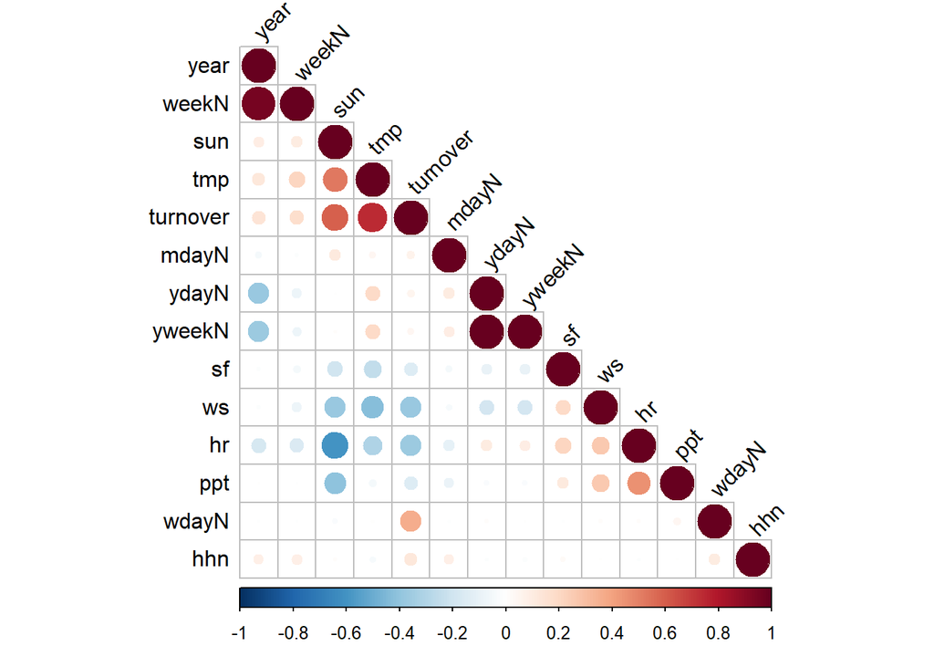

```
## $r
##             year   weekN    sun    tmp turnover   mdayN  ydayN yweekN
## year           1
## weekN       0.95       1
## sun        0.095     0.1      1
## tmp         0.13    0.21   0.52      1
## turnover    0.15    0.17   0.59   0.74        1
## mdayN     -0.043  -0.013   0.11  0.043    0.064       1
## ydayN      -0.38  -0.077 0.0042   0.19     0.05     0.1      1
## yweekN     -0.37  -0.074  0.012   0.19    0.043    0.09   0.99      1
## sf        -0.013  -0.046   -0.2  -0.25    -0.15  -0.041 -0.098 -0.098
## ws        -0.016   -0.08  -0.38  -0.43    -0.38  -0.033  -0.19  -0.19
## hr         -0.18   -0.16   -0.6  -0.31    -0.37   -0.11    0.1  0.093
## ppt       0.0043 -0.0047  -0.41 -0.048    -0.15  -0.085 -0.027 -0.028
## wdayN    -0.0053 -0.0077 -0.025 0.0092     0.36 -0.0084  0.013 0.0038
## hhn        0.085   0.088  0.017 -0.035     0.13   0.083 -0.011 -0.018
##               sf     ws     hr    ppt wdayN hhn
## year
## weekN
## sun
## tmp
## turnover
## mdayN
## ydayN
## yweekN
## sf             1
## ws          0.19      1
## hr          0.21   0.26      1
## ppt         0.11   0.26   0.45      1
## wdayN    -0.0064  0.013  0.017  0.048     1
## hhn        0.026 0.0057 -0.012 0.0067   0.1   1
##
## $p
##             year   weekN      sun     tmp turnover   mdayN   ydayN  yweekN
## year           0
## weekN          0       0
## sun       0.0016 0.00056        0
## tmp      8.3e-06 3.8e-12  1.3e-75       0
## turnover   1e-06 8.1e-09 2.7e-102  5e-188        0
## mdayN       0.16    0.68  0.00023    0.15    0.034       0
```

[output cut: 42 more lines]

```
## weekN
## sun
## tmp
## turnover
## mdayN
## ydayN
## yweekN
## sf
## ws
## hr
## ppt
## wdayN
## hhn      1
## attr(,"legend")
## [1] 0 ' ' 0.3 '.' 0.6 ',' 0.8 '+' 0.9 '*' 0.95 'B' 1
```

```r
rquery.cormat(dplyr::select_if(df, is.numeric))
```

- Bereits als Kategorien codierte Variabeln werden bevorzugt. Demnach sind die folgenden Variabeln Kandidaten für die multivariate Analyse: **year, month, wday, hl, hls, hlL.1, hr, ppt, tmp, sf, sun, ws**
- Allerdings sind diese Variabeln sind teilweise stark korreliert (40-60%) und deshalb ist deren Aussagekraft im Modell möglicherweise verzerrt. Wir behalten dies im Kopf und fahren mit den genannten Variabeln fort.

Frage: Wie stark dürfen die abhängigen Variabeln im linearen Modell korrelieren?

# 3 Lineares Regressionsmodell

Strategie: Stepwise Regression (forward selection)

```r
# Linear Model Function
linear_model <- function(df, formula, str_splitDate){

  # Train / Test split
  splitDate <- as.POSIXct(str_splitDate)
  train <- df[date < splitDate]
  test <- df[date >= splitDate]
  test.turnover <- test[,turnover]
  test[,turnover := NULL]

  range(train$date)
  range(test$date)


  # Modell fit
  lm.mod1 <- lm(formula, data = train)
  print(summary(lm.mod1))
  plot(lm.mod1)


  # Predict
  lm.mod1.pred <- predict(lm.mod1, newdata = test)
  plot(lm.mod1.pred)

  lm.mod1.res <- lm.mod1.pred - test.turnover
  ape <- abs(lm.mod1.res) / test.turnover
  mape <- median(ape)

  print(paste0("Formula: ", formula))
  print(paste0("Median APE: ", mape))



  # Plot
  plotdata <- data.table(pred = lm.mod1.pred, turnover = test.turnover, res = lm.mod1.res, ape = ape, date = test$date)

  predPlot <- ggplot(plotdata, aes(as.Date(date))) +
    geom_line(aes(y = turnover, colour = "Turnover")) +
    geom_line(aes(y = pred, colour = "Prediction")) +
    theme_bw() +
    scale_x_date(date_breaks = "1 week", date_labels =  "%d.%m.%Y") +
    theme(axis.text.x = element_text(angle = 60, hjust = 1))

  apePlot <- ggplot(plotdata, aes(as.Date(date))) +
    geom_line(aes(y = ape, colour = "Abweichung [%]")) +
    theme_bw() +
    scale_x_date(date_breaks = "1 week", date_labels =  "%d.%m.%Y") +
    theme(axis.text.x = element_text(angle = 60, hjust = 1))

  grid.arrange(predPlot, apePlot, nrow = 1)

  print(plotdata[order(-abs(res))])

}


# Global Variables
df <- df
str_splitDate <- "2019-06-01"
```

## 3.1 Model 1

```r
formula <- turnover ~ factor(month)
linear_model(df=df, formula=formula, str_splitDate=str_splitDate)
```

```
##
## Call:
## lm(formula = formula, data = train)
##
## Residuals:
##      Min       1Q   Median       3Q      Max
## -10644.7  -2756.6   -653.4   2421.0  17608.8
##
## Coefficients:
##                 Estimate Std. Error t value Pr(>|t|)
## (Intercept)       4945.1      449.1  11.011  < 2e-16 ***
## factor(month)02   1673.9      651.9   2.568   0.0104 *
## factor(month)03   3100.5      635.1   4.882 1.23e-06 ***
## factor(month)04   6939.5      640.4  10.836  < 2e-16 ***
## factor(month)05   7878.4      638.6  12.337  < 2e-16 ***
## factor(month)06  11668.1      717.1  16.270  < 2e-16 ***
## factor(month)07  13173.0      710.1  18.551  < 2e-16 ***
## factor(month)08  12017.4      710.1  16.924  < 2e-16 ***
## factor(month)09   6682.8      677.2   9.868  < 2e-16 ***
## factor(month)10   3221.0      635.1   5.072 4.73e-07 ***
## factor(month)11    840.1      646.0   1.300   0.1938
## factor(month)12   1613.4      635.1   2.540   0.0112 *
## ---
## Signif. codes:  0 '***' 0.001 '**' 0.01 '*' 0.05 '.' 0.1 ' ' 1
##
## Residual standard error: 4331 on 969 degrees of freedom
## Multiple R-squared:  0.4919, Adjusted R-squared:  0.4862
## F-statistic:  85.3 on 11 and 969 DF,  p-value: < 2.2e-16
```

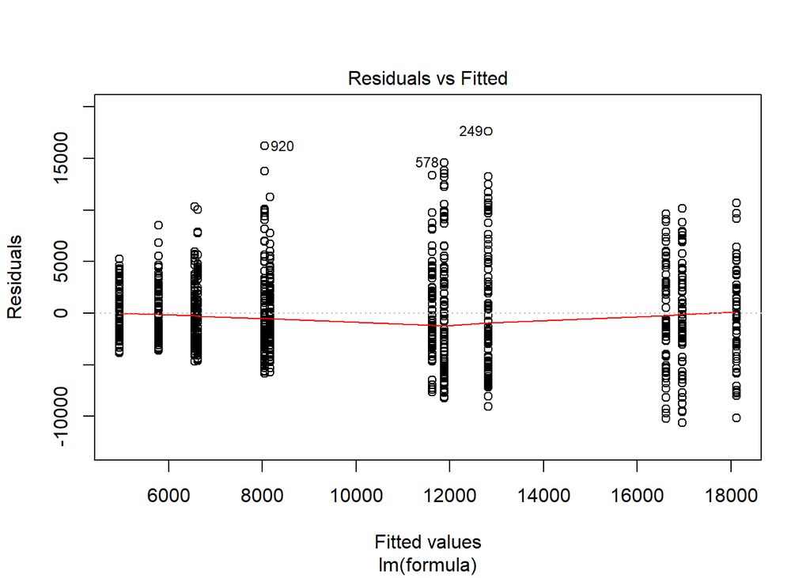

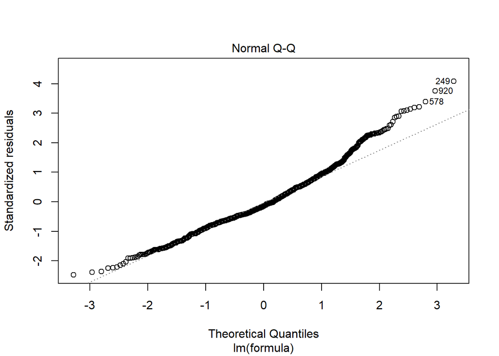

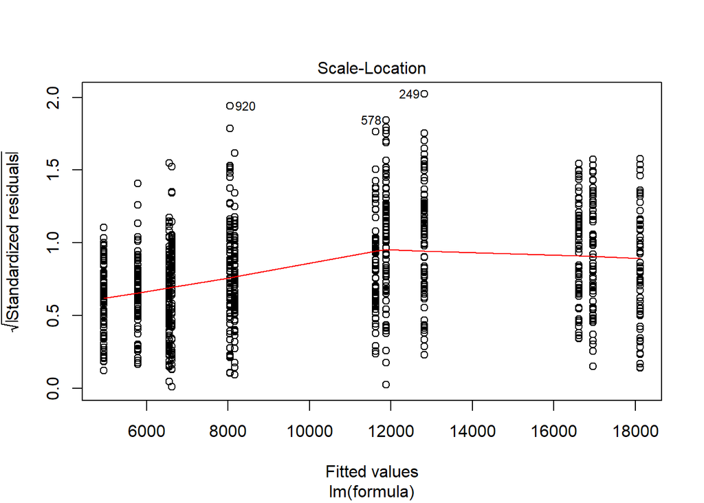

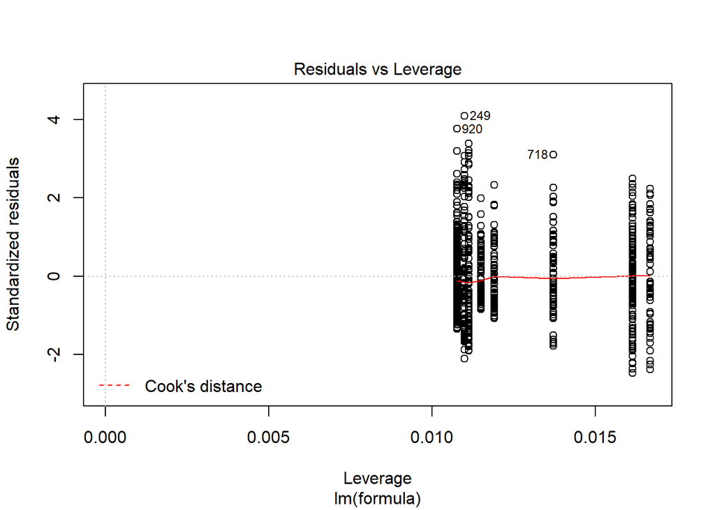

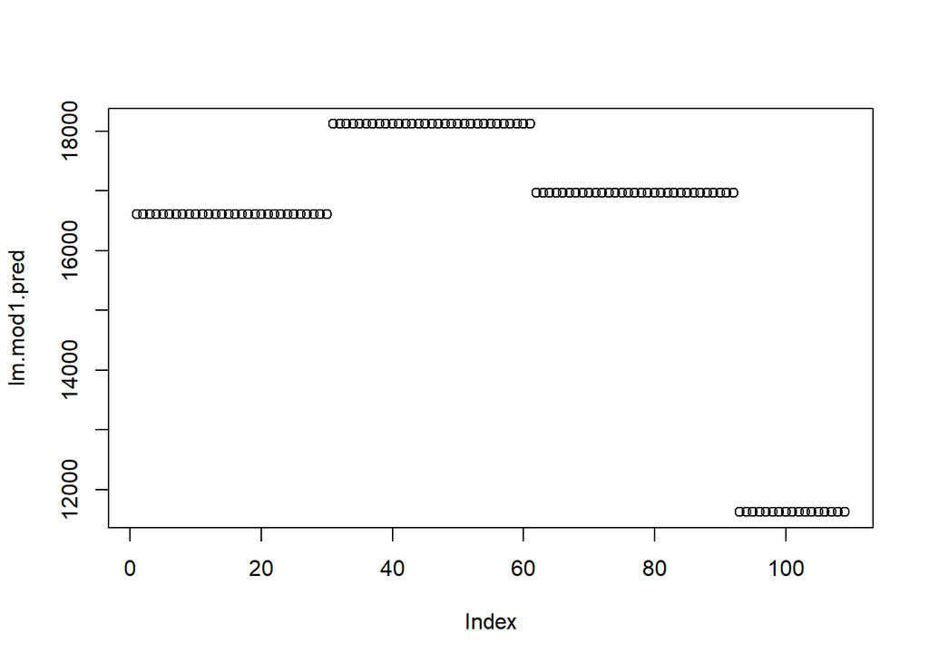

```
## [1] "Formula: ~"             "Formula: turnover"
## [3] "Formula: factor(month)"
## [1] "Median APE: 0.193529444301736"
```

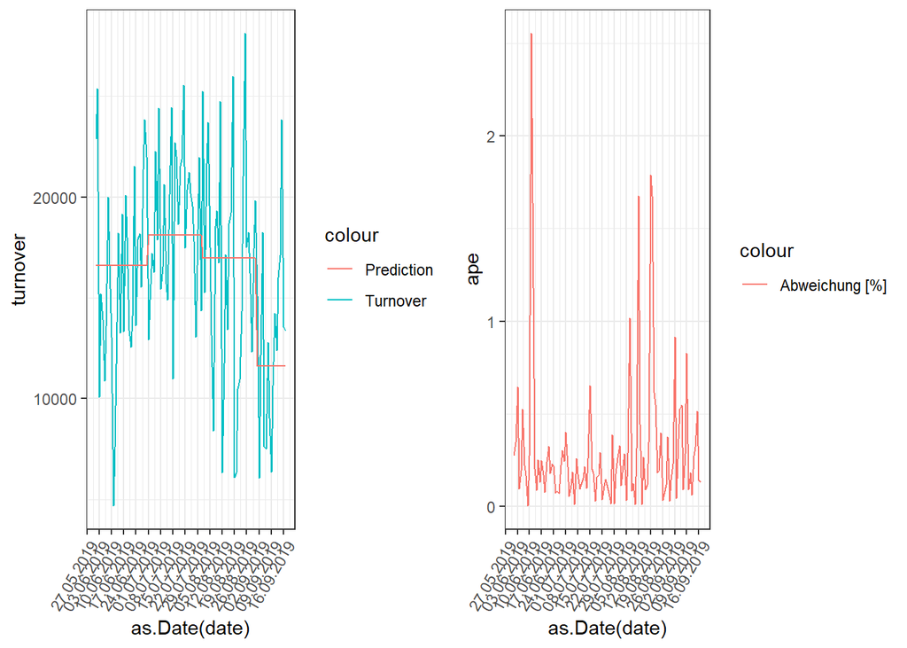

```
##          pred  turnover          res         ape       date
##   1: 11627.89 23845.214 -12217.32770 0.512359746 2019-09-15
##   2: 16613.26  4674.837  11938.42743 2.553763166 2019-06-11
##   3: 16962.54 28114.076 -11151.53689 0.396653154 2019-08-25
##   4: 16962.54  6084.565  10877.97456 1.787798374 2019-08-19
##   5: 16962.54  6335.545  10626.99365 1.677360500 2019-08-20
##  ---
## 105: 18118.14 18379.531   -261.39188 0.014221901 2019-07-29
## 106: 18118.14 17891.018    227.12177 0.012694737 2019-07-06
## 107: 16962.54 16750.938    211.60083 0.012632178 2019-08-10
## 108: 16962.54 17129.665   -167.12607 0.009756529 2019-08-14
## 109: 16613.26 16649.903    -36.63858 0.002200528 2019-06-09
```

## 3.2 Model 2

```r
formula <- turnover ~ factor(month) + factor(wday)
linear_model(df=df, formula=formula, str_splitDate=str_splitDate)
```

```
##
## Call:
## lm(formula = formula, data = train)
##
## Residuals:
##      Min       1Q   Median       3Q      Max
## -11360.8  -2134.9   -231.8   1711.3  19113.4
##
## Coefficients:
##                 Estimate Std. Error t value Pr(>|t|)
## (Intercept)       3066.1      466.1   6.578 7.81e-11 ***
## factor(month)02   1558.3      544.8   2.860  0.00433 **
## factor(month)03   2916.2      531.0   5.492 5.09e-08 ***
## factor(month)04   6776.6      535.2  12.661  < 2e-16 ***
## factor(month)05   7864.5      533.7  14.735  < 2e-16 ***
## factor(month)06  11520.5      599.5  19.215  < 2e-16 ***
## factor(month)07  12988.7      593.5  21.884  < 2e-16 ***
## factor(month)08  12018.9      593.5  20.250  < 2e-16 ***
## factor(month)09   6466.3      566.1  11.423  < 2e-16 ***
## factor(month)10   3121.5      530.8   5.881 5.63e-09 ***
## factor(month)11    722.7      540.1   1.338  0.18117
## factor(month)12   1356.7      531.0   2.555  0.01078 *
## factor(wday)Do     388.4      431.2   0.901  0.36799
## factor(wday)Fr    2517.8      431.3   5.837 7.25e-09 ***
## factor(wday)Mi     705.8      431.9   1.634  0.10251
## factor(wday)Mo    -475.4      434.4  -1.094  0.27406
## factor(wday)Sa    4475.6      432.1  10.359  < 2e-16 ***
## factor(wday)So    6350.2      431.2  14.727  < 2e-16 ***
## ---
## Signif. codes:  0 '***' 0.001 '**' 0.01 '*' 0.05 '.' 0.1 ' ' 1
##
## Residual standard error: 3619 on 963 degrees of freedom
## Multiple R-squared:  0.6474, Adjusted R-squared:  0.6412
## F-statistic:   104 on 17 and 963 DF,  p-value: < 2.2e-16
```

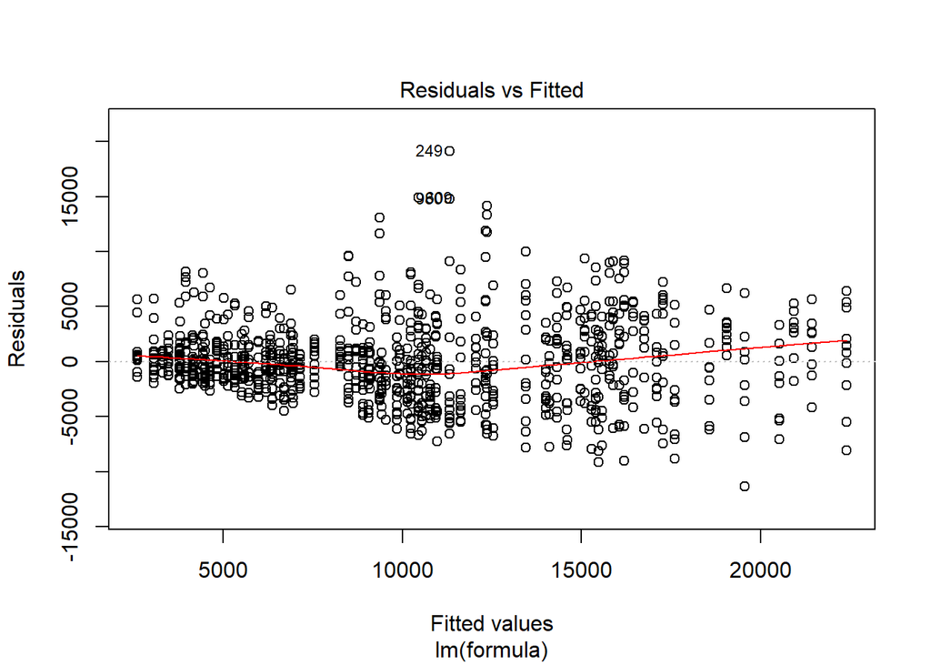

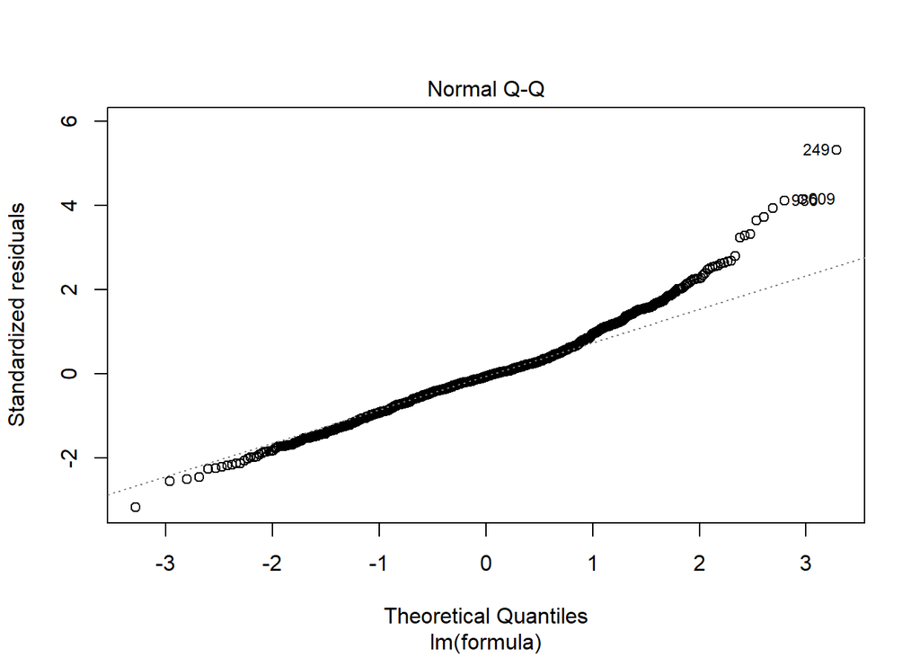

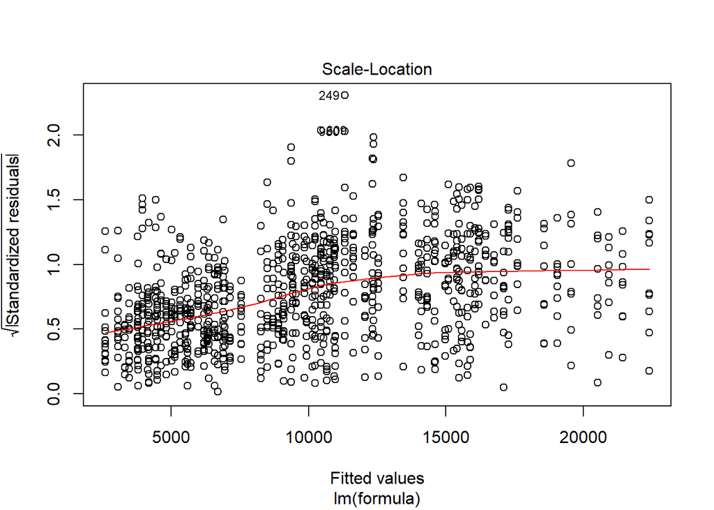